# R2D2 Prior for Gambia dataset

In this example, we will demonstrate the use of the R2D2 prior on the *Gambia* dataset (Thomson et.al., 1999) from the *geoR* package (Ribeiro et. al., 2007). There are $n=2035$ children in this data set with binary response variable $Y_i$ which equals 1 if child $i$ tested positive for malaria and 0 otherwise. There are $p=5$ fixed effect covariates including age, indicator of using a bed net, ``greenness" of village and indicator of a health center in the area. There is also the $L_1=65$ villages that each child lived in along with the spatial location of each village.

We model the village effect as a spatial term so the linear predictor is
$$\mbox{logit}\{P(Y_i=1|\eta_i)\} = \eta_i = \beta_0 + {\bf X}_i\boldsymbol\beta+\alpha_{g_i}$$
where $g_i$ is the village of the $i$th child and we assume $\mbox{E}(\alpha_i)=0$ and $\mbox{Var}(\alpha_i)=\sigma^2_\alpha$ for all $i$ and exponential spatial correlation $C_{ij}=\mbox{Cor}(\alpha_i,\alpha_j) = e^{-d_{ij}/\rho}$ where $d_{ij}$ is the distance between village $i$ and $j$ and $\rho>0$ is the spatial range parameter. Then the full prior specification for R2D2 is
$$\begin{multline}
\beta_0\sim\mbox{Normal}(\mu_0,\tau_0^2),\
\boldsymbol\beta\sim\mbox{Normal}(0, \tfrac15\phi_1W{\bf I}_5),\
\boldsymbol{\alpha}\sim\mbox{Normal}(0,\phi_2 W{\bf C}),\\ \rho\sim\mbox{Uniform}(0, 2r), W\sim\mbox{GBP}(a^*, b^*, c^*, d^*),\ (\phi_1,\phi_2)\sim\mbox{Dirichlet}(\xi_1,\xi_2)
\end{multline}$$
for hyper-parameters set to $\mu_0=0,\tau_0^2=3$, $\xi_1=\xi_2=1$ and $r$ is the maximum distance between pairs of villages.

```r
library(geoR)
data(gambia)

Y=gambia$pos
X=scale(gambia[,c(1,2,4:8)])

## Create the random effect
s.ind <- numeric(length(Y))

for(i in 1:65){
  for(j in 1:length(Y)){
    if(X[j,2]==unique(X[,2])[i]){
      s.ind[j] = i
    }
  }
}

## Create spatial correlation matrix
X.loc <- unique(X[,1:2])

# Max distance
#r = max(C)
r = 0.986

# Drop locations
X <- X[,-(1:2)]

n=length(Y) # number of data points
p=ncol(X)# number of fixed effects
q=1 # number of random effects
L=length(unique(s.ind)) # number of levels in random effect
```

## Find $(a^*,b^*,c^*,d^*)$

```r
library(r2d2glmm)

a = 1
b = 1

params <- WGBP(a, b, b0=logit(mean(Y)), link="Logistic")
params
```

```
#> [1] 1.4722786 0.6494361 0.7887448 1.6711417
```

## Fit model in JAGS

```r
library(rjags)
data = list(Y=Y, X=X, n=n, p=ncol(X), s.ind = s.ind, L=length(unique(s.ind)),
            X.loc = X.loc, params = params, r=r)

model_string <- textConnection("model{

##Likelihood
for(i in 1:n){
  Y[i] ~ dbern(1/(1+exp(-mu[i]-alpha[s.ind[i]])))
  mu[i] <- beta0 + inprod(X[i,],beta[])
}

alpha[1:L] ~ dmnorm.vcov(zero[1:L], dd[2]*W*C[1:L,1:L])

## Create correlation matrix

for(i in 1:L){
  C[i,i] <- 1
  zero[i] <- 0
  }

for(i in 1:(L-1)){
  for(j in (i+1):L){

    C[i,j] <- exp(-sqrt((X.loc[i,1] - X.loc[j,1])^2 + (X.loc[i,2] - X.loc[j,2])^2)/rho)
    C[j,i] <- exp(-sqrt((X.loc[i,1] - X.loc[j,1])^2 + (X.loc[i,2] - X.loc[j,2])^2)/rho)
  }
}

##Priors

  V ~ dbeta(params[1], params[2])
  W <- (V/(1-V))^(1/params[3])*params[4]

  for(i in 1:2){delta[i] <- 1}
  dd ~ ddirch(delta)

  beta0 ~ dnorm(0,1/3)
  rho ~ dunif(0,2*r)
  for(j in 1:p){beta[j] ~ dnorm(0, 1/(W*dd[1])/p)}

}")

inits <- list(beta=rep(0,p), alpha=rep(0,L))
model <- jags.model(model_string,data = data, inits=inits, n.chains=1)
update(model, 10000)

params <- c("beta", "alpha", "beta0", "W", "dd", "rho")
samples <- coda.samples(model,
                        variable.names=params,
                        n.iter=40000)
```

## Check convergence

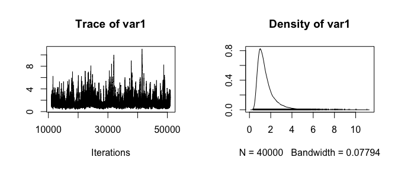

```r
plot(samples[[1]][,1]) # W
```

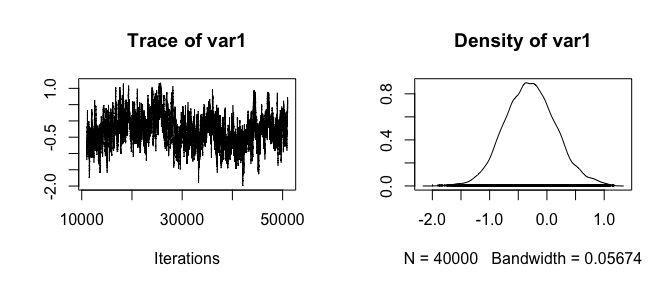

```r
plot(samples[[1]][,1+10]) # alpha_10
```

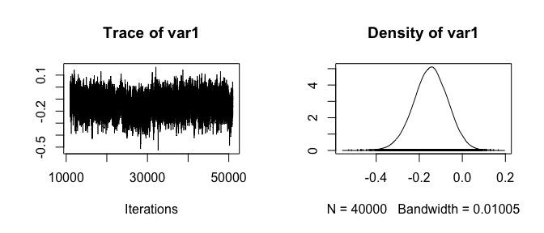

```r
plot(samples[[1]][,1+65+3]) # beta_3
```

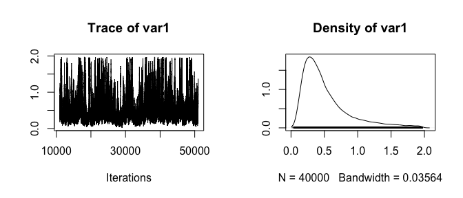

```r
plot(samples[[1]][,1+65+5+4]) # rho
```

## Plot results

```r
library(dplyr)
```

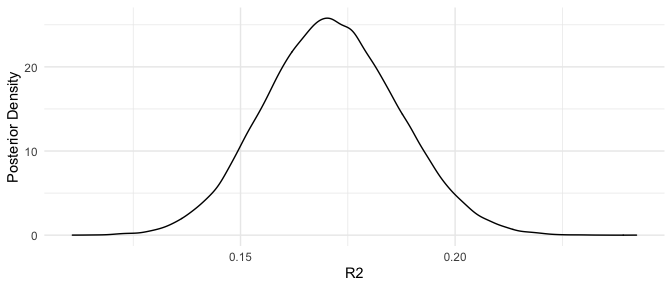

```r
library(ggplot2)
bayes_R2 <- function(X, p, L, ind, samples){

  n = dim(X)[1]

  expit <- function(x){1/(1+exp(-x))}

  b0s <- as.matrix(samples[[1]][,1+p+L+1])
  betas <- as.matrix(samples[[1]][,(1+L+1):(1+L+p)])
  alphas <- as.matrix(samples[[1]][,2:(L+1)])

  Z <- matrix(0, nrow=n, ncol=L)

  for(i in 1:n){Z[i, ind[i]] <- 1}

  etas <- betas%*%base::t(X) + alphas%*%base::t(Z)
  etas <- sweep(etas, 1, b0s, "+")

  y_pred <- expit(etas)
  y_var <- y_pred * (1-y_pred)
  M <- apply(y_pred,1,var)
  V <- apply(y_var,1,mean)
  return(M/(M+V))

}

plt.df <- tibble(r2 = bayes_R2(X,p,L,s.ind,samples),
                 W = as.vector(samples[[1]][,1]),
                 b1 = as.vector(samples[[1]][,1+65+1]),
                 b2 = as.vector(samples[[1]][,1+65+2]),
                 b3 = as.vector(samples[[1]][,1+65+3]),
                 b4 = as.vector(samples[[1]][,1+65+4]),
                 b5 = as.vector(samples[[1]][,1+65+5]))


ggplot(data = plt.df, aes(x=r2))+
  geom_density()+
  xlab("R2")+
  ylab("Posterior Density")+
  theme_minimal()
```

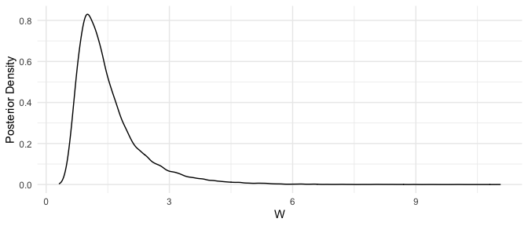

```r
ggplot(data = plt.df, aes(x=W))+
  geom_density()+
  xlab("W")+
  ylab("Posterior Density")+
  theme_minimal()
```

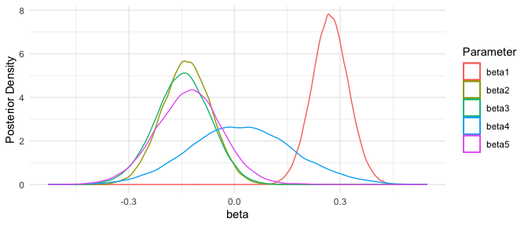

```r
ggplot(data = plt.df)+
  geom_density(aes(x=b1, color="beta1"))+
  geom_density(aes(x=b2, color="beta2"))+
  geom_density(aes(x=b3, color="beta3"))+
  geom_density(aes(x=b4, color="beta4"))+
  geom_density(aes(x=b5, color="beta5"))+
  xlab("beta")+
  ylab("Posterior Density")+
  labs(color = "Parameter")+
  theme_minimal()
```